# What are (Not) Theories & Models?

Felix Schönbrodt

felix.schoenbrodt@psy.lmu.de

Ludwig-Maximilians-Universität München

2025-10-31

# What is a theory?

> Like so many words that are bandied about, the word theory threatens to become meaningless. Because its referents are so diverse - including everything from minor working hypotheses, through comprehensive but vague and unordered speculations,to axiomatic systems of thought - use of the word often obscures rather than creates understanding.

> *Merton (1967, p. 39)*

Maybe an easier question for the start: What is not a theory?

Cited from Sutton, R. I., & Staw, B. M. (1995). What theory is not. Administrative Science Quarterly, 40(3), 371. https://doi.org/10.2307/2393788

## What is *not* a theory?

### 1. References To Theory Are Not Theory

*(Note: While the following features of a scholarly article do not constitute a theory, they might be important in their own right)*

> A manuscript that Robert Sutton edited had strong data, but all three reviewers emphasized that it had “weak theory” and “poorly motivated hypotheses.” The author responded to these concerns by writing a new introduction that added citations to many papers containing theory and many terms like “psycho-social theory,” “identity theory,” and “social comparison theory.”

> **But it still contained no discussion of what these theories were about and no discussion of the logical arguments why these theories led to the author’s predictions.** The result was that this paper contained almost no theory, despite the author’s assertion that much had been added.

**Solution**:

> Authors need to explicate which concepts and causal arguments are adopted from cited sources and how they are linked to the theory being developed or tested.

Sutton, R. I., & Staw, B. M. (1995). What Theory is Not. Administrative Science Quarterly, 40(3), 371. https://doi.org/10.2307/2393788

## What is *not* a theory?

### 2. Data Are Not Theory

> Empirical evidence plays an important role in confirming, revising, or discrediting existing theory and in guiding the development of new theory. But observed patterns like beta weights, factor loadings, or consistent statements by informants rarely constitute causal explanations.

> Kaplan (1964) asserted that theory and data each play a distinct role in behavioral science research: **Data describe *which* empirical patterns were observed and theory explains *why* empirical patterns were observed or are expected to be observed.**

In our words: Repeated patterns in data *establish* phenomena. They do not explain them.

Sutton, R. I., & Staw, B. M. (1995). What Theory is Not. Administrative Science Quarterly, 40(3), 371. https://doi.org/10.2307/2393788

## What is *not* a theory?

### 3. Lists of Variables or Constructs Are Not Theory

> Papers […] often are written as if well-defined variables or constructs, by themselves, are enough to make theory. Sometimes the list of variables represents a logical attempt to cover all or most of the determinants of a given outcome or process.

> Such lists may be useful catalogs of variables that can be entered as predictors or controls in multiple regression equations […], but they do not constitute theory.

**Notes**:

- Lists of constructs (without an explicit definition of their causal relationship) often are called a *framework*.
- When we build our models, we will also create tables of constructs and variables. But that alone is not yet a theory!

Sutton, R. I., & Staw, B. M. (1995). What Theory is Not. Administrative Science Quarterly, 40(3), 371. https://doi.org/10.2307/2393788

## What is *not* a theory?

### 4. Diagrams (Alone) Are Not Theory

**This is an extension of (3) “List of constructs”: Put each construct that you deem relevant into a box and draw arrows between all constructs (because in a complex system everything is connected with everything)**

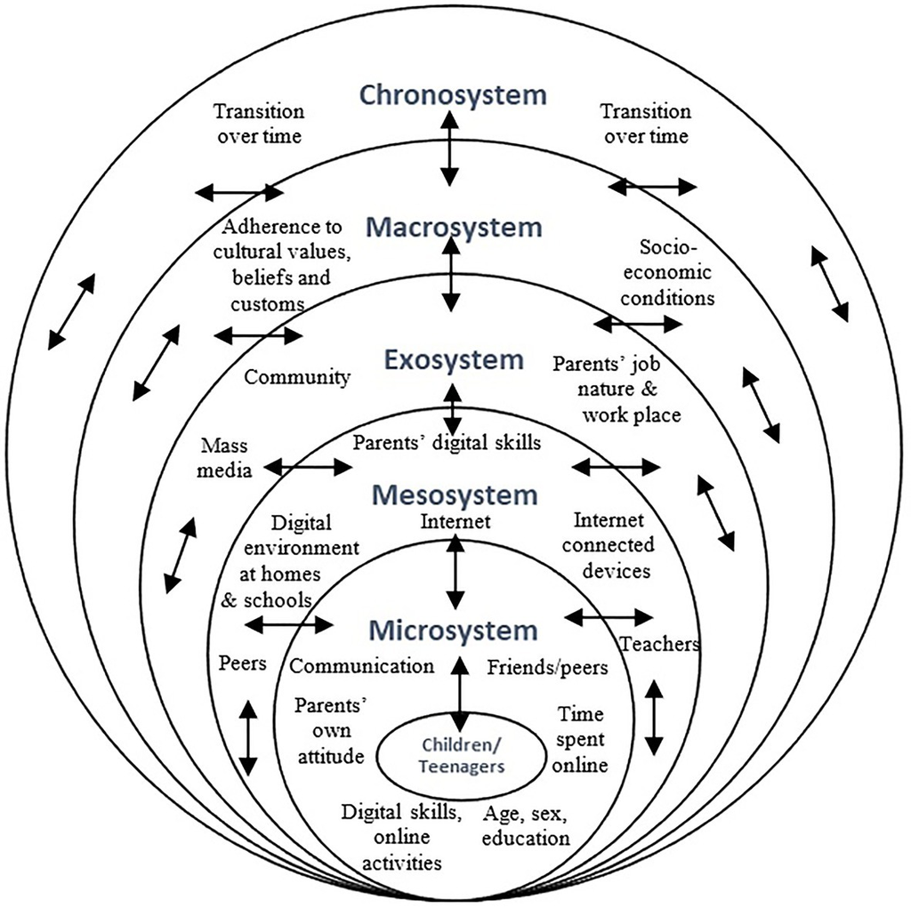

Iqbal, S. et al. (2021). https://doi.org/10.3389/fpsyg.2021.620838

## 4. Diagrams (Alone) Are Not Theory

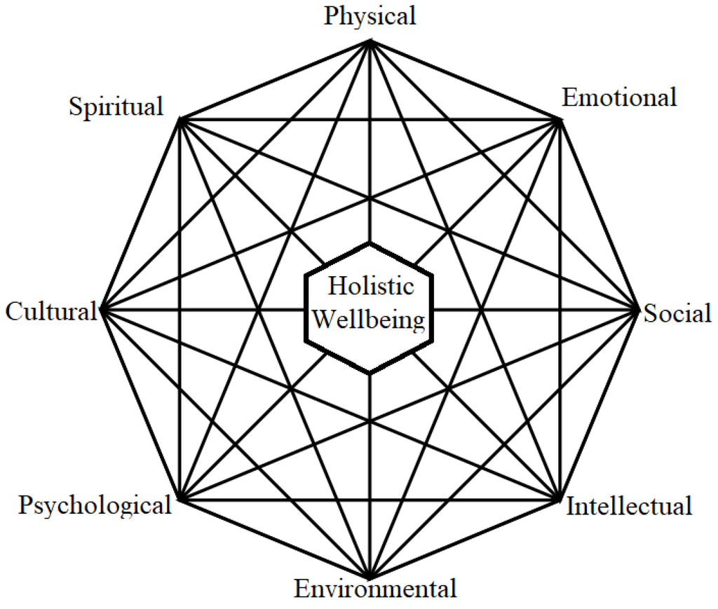

Figure 1. Holistic wellbeing model for school education.

Norozi, S. A. (2023). The Nexus of Holistic Wellbeing and School Education: A Literature-Informed Theoretical Framework. Societies, 13(5), 113. https://doi.org/10.3390/soc13050113

## 4. Diagrams (Alone) Are Not Theory

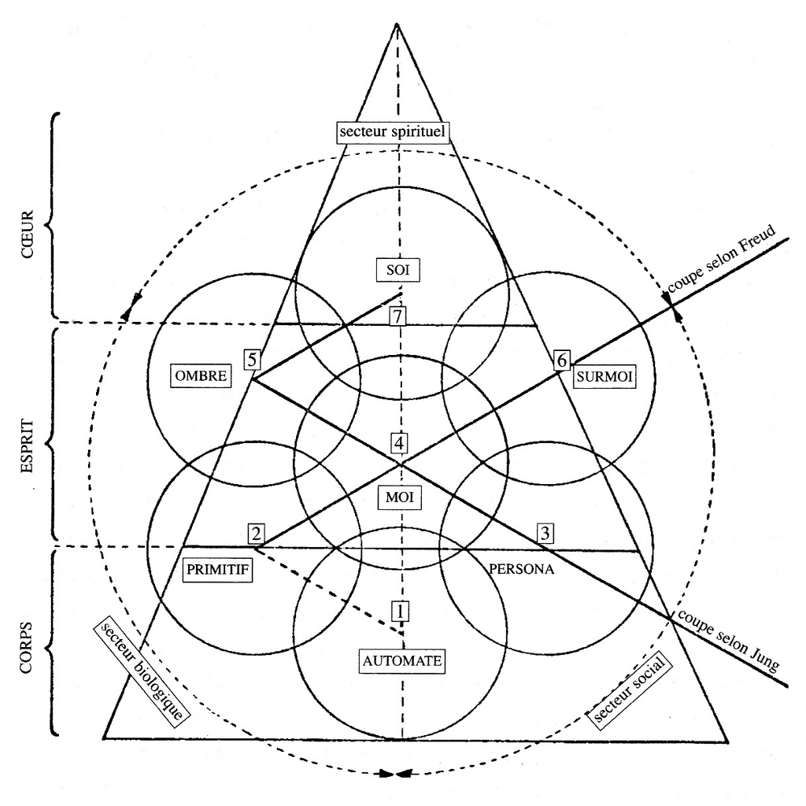

CBCB, CC BY-SA 3.0 https://creativecommons.org/licenses/by-sa/3.0, via Wikimedia Commons

## 4. Diagrams (Alone) Are Not Theory

[figure not shown]

http://alchemicaldiagrams.blogspot.com/2010_12_01_archive.html

## What is *not* a theory? 4

### 4. Diagrams (Alone) Are Not Theory

> Diagrams or figures can be a valuable part of a research paper but also, by themselves, rarely constitute theory. […]

> More helpful are figures that show causal relationships in a logical ordering, so that readers can see a chain of causation or how a third variable intervenes in or moderates a relationship. Also useful are temporal diagrams showing how a particular process unfolds over time. […]

> As Whetten (1989) suggested, while boxes and arrows can add order to a conception by explicitly delineating patterns and causal connections, **they rarely explain *why* the proposed connections will be observed. Some verbal explication is almost always necessary**.

**Discussion**: Are then VAST displays on their own sufficient to constitute a theory?

Sutton, R. I., & Staw, B. M. (1995). What Theory is Not. Administrative Science Quarterly, 40(3), 371. https://doi.org/10.2307/2393788

## What is *not* a theory?

### 5. Hypotheses (or Predictions) Are Not Theory.

> Hypotheses can be an important part of a well-crafted conceptual argument. They serve as crucial bridges between theory and data, making explicit how the variables and relationships that follow from a logical argument will be operationalized. […]

> Hypotheses do not (and should not) contain logical arguments about why empirical relationships are expected to occur. Hypotheses are concise statements about *what* is expected to occur, not *why* it is expected to occur.

Sutton, R. I., & Staw, B. M. (1995). What Theory is Not. Administrative Science Quarterly, 40(3), 371. https://doi.org/10.2307/2393788

# But, then: What is a theory?

## Theories as causal explanations

> “It may be said… that an explanation is not fully adequate unless its explanans […] could have served as a basis for predicting the phenomenon under consideration.

> … not merely to record the phenomena of our experience, but to learn from them, by basing upon them theoretical generalizations which enable us to anticipate new occurrences and to control, at least to some extent, the changes in our environment”

> *Hempel & Oppenheim, 1948, (p. 138)*

Put in other words: Explanatory theories aim at causal/mechanistic understanding that supports prediction and, under suitable scope conditions, control.

## TCM: A methodology for constructing theories

```
%%{
  init: {
    'theme': 'base',
    'flowchart': { 'curve': 'natural' }
  }
}%%
flowchart LR
  T(Theory)
  P(Phenomena)
  D(Data)

  T -- "Explanation" --> P
  P -- "Abduction" --> T
  P -- "Prediction" --> D
  D -- "Generalization" --> P
```

**Phenomena**: Stable and general features of the world in need of explanation. Can be understood as robust generalizations of patterns in empirical data. They are the explanatory targets for scientific theories (the *explanandum*). In psychology often called “effects”.

**Data**: Relatively direct observations. Refer to *particular* empirical patterns in concrete data sets rather than empirical generalizations (which would be phenomenona).

**Explanatory Theories** are constructed to explain the empirical phenomena that are evidenced by data (i.e., they are the *explanans*). Explanatory theories can be expressed in terms of a set of linked propositions referring to latent psychological constructs. At least one of these propositions expresses a general principle.

See Borsboom et al. (2021). https://doi.org/10.1177/1745691620969647

## Definitions (1)

**What is an (explanatory) theory? (Borsboom et al. (2021) definition)**

A theory is a set of statements about the relationship(s) between two or more constructs with a nomological (i.e. law-like) character. (*explanans*)

**Musfeld et al. (2026) definition**

A set of interrelated propositions about (aspects of) the world that aim to explain and predict certain phenomena.

Dissecting the dense definitions:

- Theories are not about specific measurements or operationalizations: they are about (a) latent *constructs*, and (b) explains *phenomena* (generalizable patterns in data).
- “Statements”: Typically these are *causal* statements (if-then), but the definition is broad and includes also other statements (e.g., correlational).

Borsboom et al. ([2021](https://doi.org/10.1177/1745691620969647)); Musfeld et al. ([2026](https://osf.io/preprints/psyarxiv/e7tdc_v4)).

## What is a model?

A {formal|mathematical|computational} model is a precise, mathematical or algorithmic representation of the theory’s principles and relationships. It serves as a bridge between abstract theoretical principles and the empirical world.

As theories are about constructs, there is a gap between theory and implemented models: We need more assumptions to implement a model in computer code and to make it empirically testable. These are typically assumptions about *operationalization* (how to measure constructs) and *auxiliary assumptions* (additional assumptions that are not part of the core theory, but are needed to implement it, such as specific functional forms).

Filling the gaps between theory and implemented model is called model specification. There is no 1-to-1 mapping of a theory to a derived model: Multiple models can satisfy the axioms and constraints of a theory.

# “Der Wirklichkeit Gewalt antun”

## “Der Wirklichkeit Gewalt antun”

> “Die Wahrheit liegt in der uns umgebenden Wirklichkeit unmittelbar vor uns. Diese können wir aber unverändert nicht gebrauchen. Eine lückenlose Beschreibung der Wirklichkeit wäre zugleich das wahrste und unnützste Ding von der Welt und gewiß keine Wissenschaft. Wir müssen der Wirklichkeit und damit der Wahrheit Gewalt antun, wenn wir sie wissenschaftlich verwerten wollen. Wir müssen die Unterscheidung von wesentlich und unwesentlich einführen, die es in der ganzen Natur nicht gibt. In ihr ist alles gleich wesentlich. Indem wir die uns wesentlich erscheinenden Zusammenhänge aufsuchen, ordnen wir zugleich den Stoff übersichtlich. Dann treiben wir Wissenschaft.”

> (von Uexküll, 1909, S. 58)

[figure not shown]

von Uexküll, J. (1909). Umwelt und Innenwelt der Tiere. Berlin: J. Springer, p. 58. Quote found in Smaldino ([2023](https://press.princeton.edu/books/paperback/9780691224145/modeling-social-behavior))

## “Der Wirklichkeit Gewalt antun”

### Popper’s version

Karl Popper once described science “**as the art of systematic over-simplification — the art of discerning what we may with advantage omit**”.

Sir Karl Popper, 1902 - 1994

Popper, 1988, p. 44

## “Der Wirklichkeit Gewalt antun”

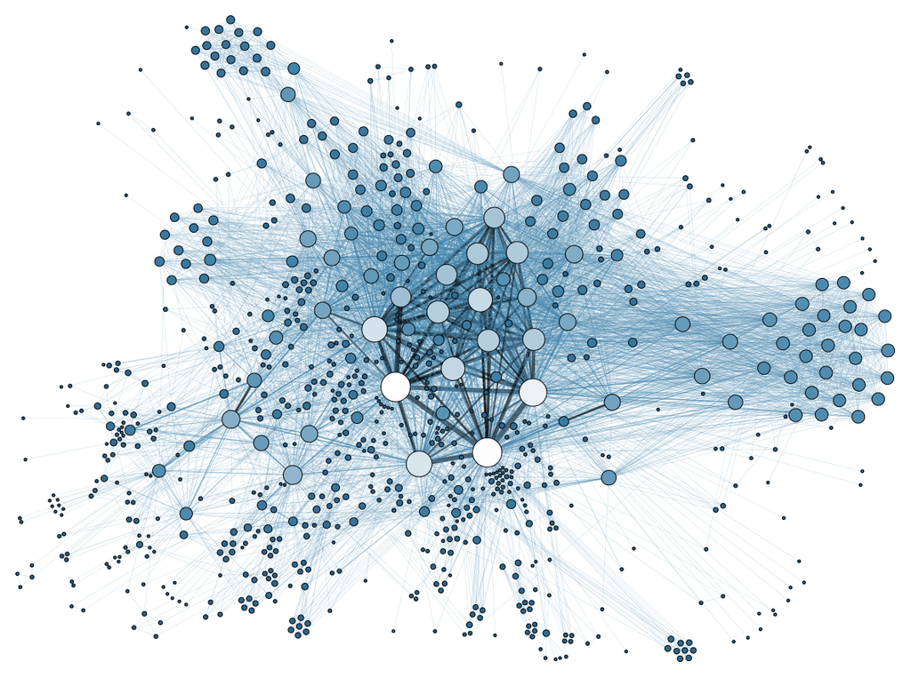

## “Der Wirklichkeit Gewalt antun”

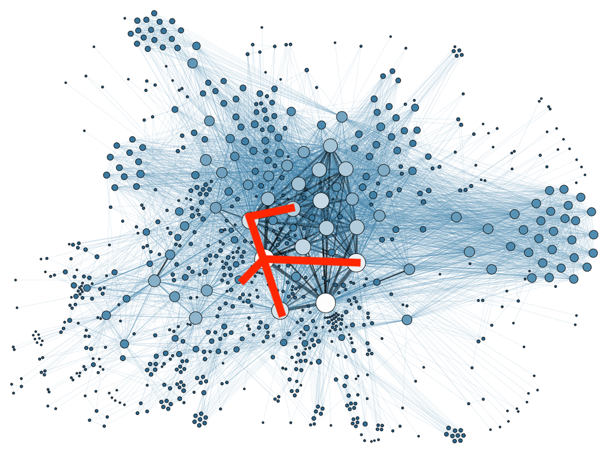

## “Der Wirklichkeit Gewalt antun”

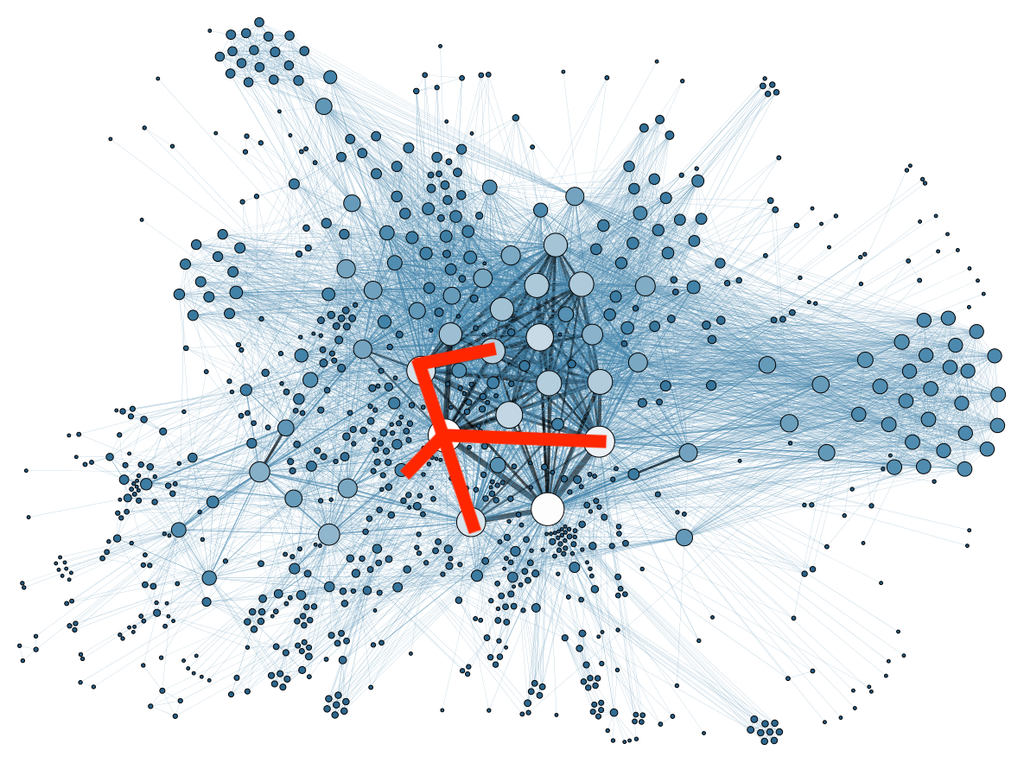

- We want to distill those concepts that are most useful to explain parts of the human psyche.
- (We will learn later what „explain“ means).
- These concepts are tools that guide our attention towards certain features, which we might not have seen before.
- They help us to organize our language and our reasoning about people.

## The map and the territory

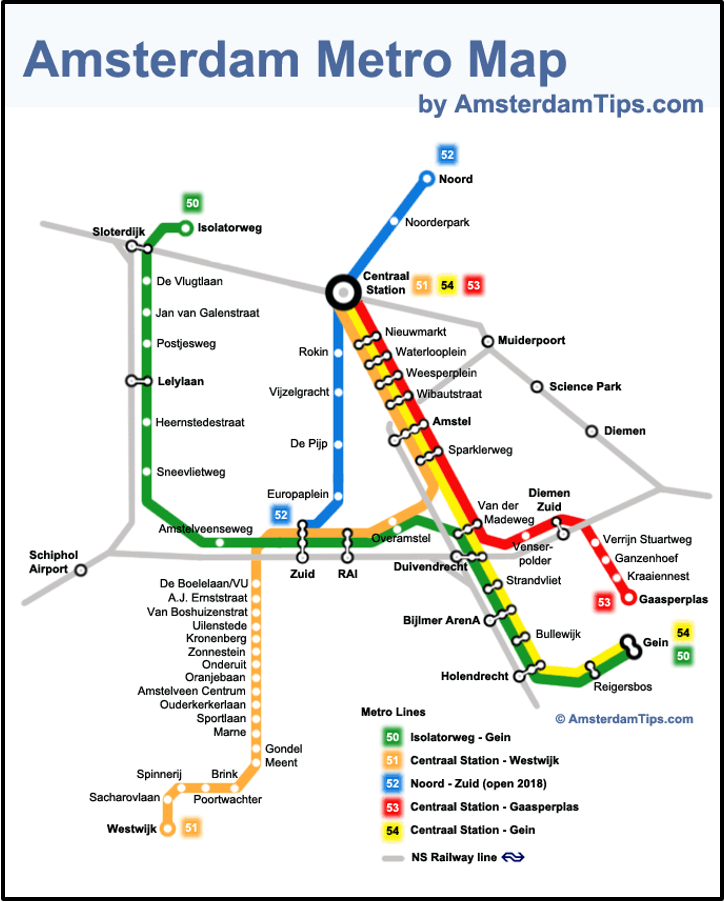

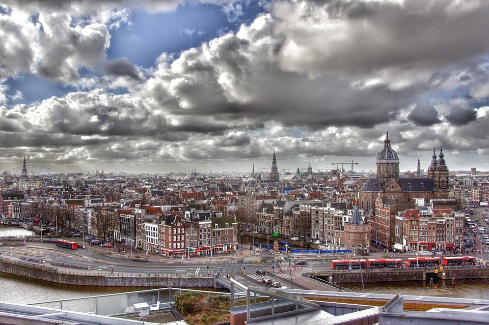

**Let’s not confuse the map with the territory!**

paraphrased from Alfred Korzybski (1933) “Science and Sanity: An Introduction to Non-Aristotelian Systems and General Semantics”

## The map and the territory

> „A language is like a map; it is not the territory represented, but it may be a good map or a bad map. If the map shows a different structure from the territory represented […] then the map is worse than useless, as it misinforms and leads astray. One who made use of it could never be certain of reaching his destination.“ (Korzybski, 1933, p. 375)

## Models vs Reality

**All models are wrong, but some models are useful.**

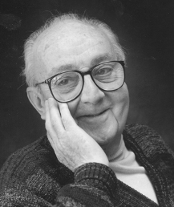

Georg Box (1919 - 2013)

Image CC-BY-SA 3.0 by DavidMCEddy (Wikimedia Commons)

## *Useful* (for a specific purpose), not *true*

> “His design for a London underground railway was initially rejected as too revolutionary. Today, his idea has gained worldwide acceptance: Beck simplified the route (only horizontal, vertical and diagonal lines) and ignored exact distances.”

[figure not shown]

→ By omission of details (and making the map *less* realistic) the map got *more useful*!

Infographic and quote from [Die ZEIT](https://www.zeit.de/2023/47/infografiker-kartograph-forscher-illustration)

## Group work (10 min.)

**How can we ensure that we do not create a purely self-referential system of symbols that does not refer to reality any more?**

Of course we can play the mathematician’s game (and might have a lot of fun meanwhile). But ultimately, if we want to understand and explain the human psyche, we need to make sure that our constructs are grounded in reality.

How can this grounding happen?

## Explicating a verbal theory into formal model(s)

### Example: van Dongen et al (2023) on Ego Depletion

- The regulatory resource theory pertains to **self-control**: cognitive processes that inhibit and suppress immediate thoughts, impulses, expression of emotions, and behaviors that deviate from standards or goals.
- The theory postulates that one’s ability for self-control depends on a **finite resource**: a stored supply of energy, for which some use the term willpower. Every act of self-control reduces the amount of willpower, so that one’s ability to inhibit or suppress the next unwanted impulse is diminished
- The theory is said to explain the **phenomenon of ego depletion**: people perform worse on a task that requires self-control, right after having done something else that used this resource.

Abridged from van Dongen et al. (2022). Improving psychological explanations. *PsyArXiv.* https://doi.org/10.31234/osf.io/qd69g

### Key theoretical principles of the verbal theory

1. there is a domain-general “resource” called willpower ($W$)
2. tasks requiring willpower deplete this resource (e.g., a task that requires self-control depletes the resource, but a task that requires no self-control does not), and
3. the resource is replenished at some rate after the task ends.

To these, we add the following auxiliary assumptions:

- willpower $W$ is a positive valued quantitative variable ($W \in \mathbb{R}^{+}$)
- willpower changes continuously in time, and
- willpower has a default value when at rest ( i.e., when there is no task that requires willpower; $W^r$).

van Dongen et al. (2022). https://doi.org/10.31234/osf.io/qd69g

### Multiple possible implementations

The theoretical key principles are not precise enough yet to program an implementation - e.g.: Is the decrease of the resouce linear or curved? How fast does the resource recover under rest?

These additional auxiliary assumptions (which are not in the core of the theory) can lead to very different possible implementations - all of which are compatible with the theory:

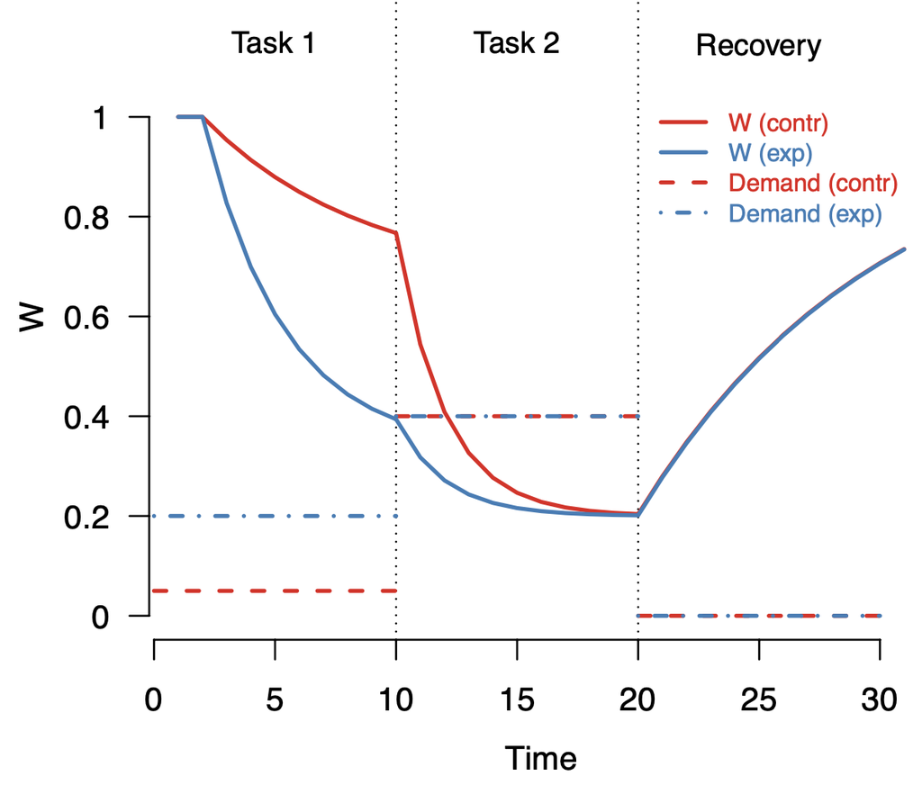

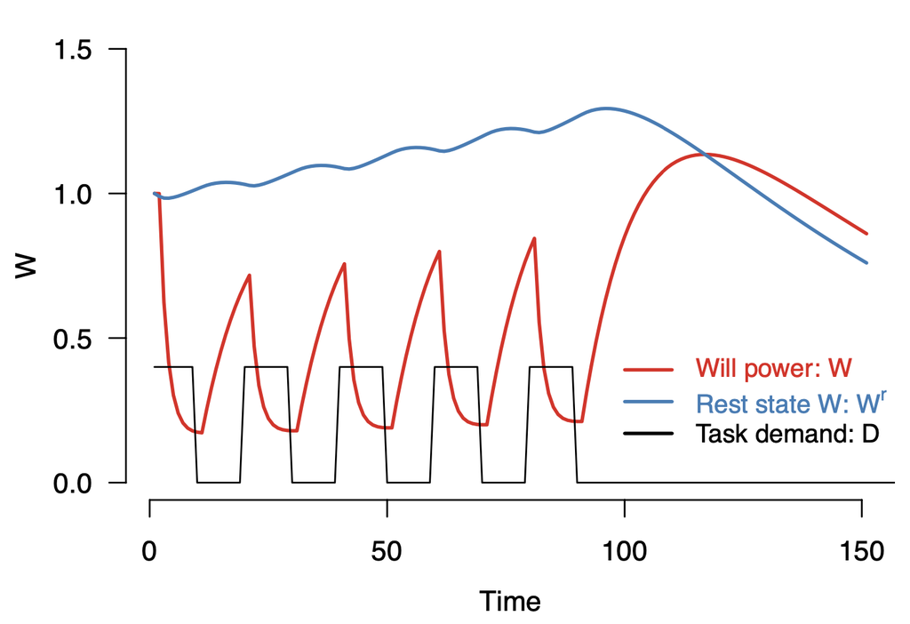

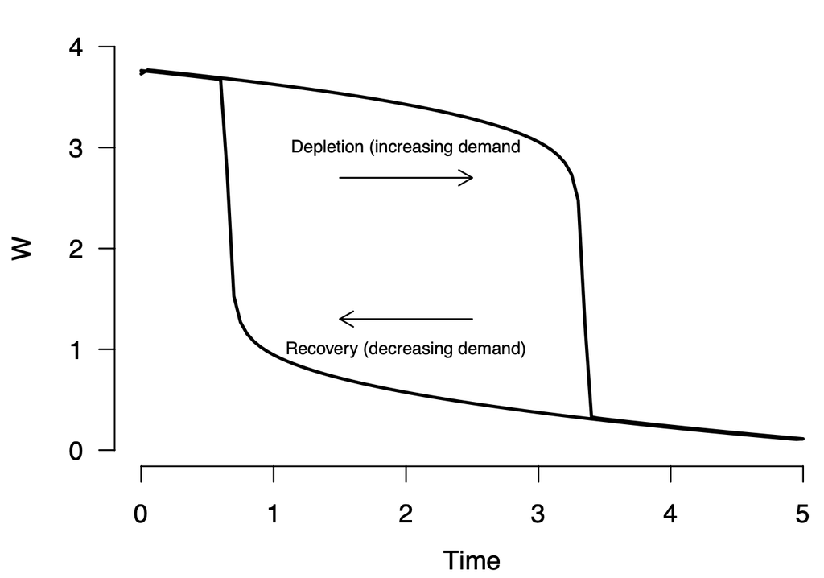

https://github.com/jmbh/explanationpaper

## Narrative - theory - model

### “Die Aura des assoziativ Mitgedachten”

> In der sozialwissenschaftlichen Literatur finden sich oft Argumente, die gegen eine Formalisierung sprechen, wie z.B. die folgende Bemerkung: “Was bei der Formalisierung notwendig verloren geht, ist die Aura des assoziativ Mitgedachten, die verbale Aussagen stets umgibt, über ihren ausdrücklichen Gehalt hinaus mit Wirklichkeit sättigt und auch in Grenzfällen noch zutreffend erscheinen lässt” (Mayntz 1967, p. 28, vgl. auch Harbordt 1974, p. 271).

> Solche Kritikpunkte können wir nicht nachvollziehen. (…) **Wenn man daran interessiert ist, “die Aura des assoziativ Mitgedachten” zu erhalten, ist schöngeistige Literatur ein geeigneteres Betätigungsfeld als Wissenschaft**.

*(Manhart, 2007)*

Manhart, K. (2007). Theorie, Modell, Formalisierung. https://www.klaus-manhart.de/mediapool/28/284587/data/01-theorie-modell_2_.pdf

## Narrative - theory - model

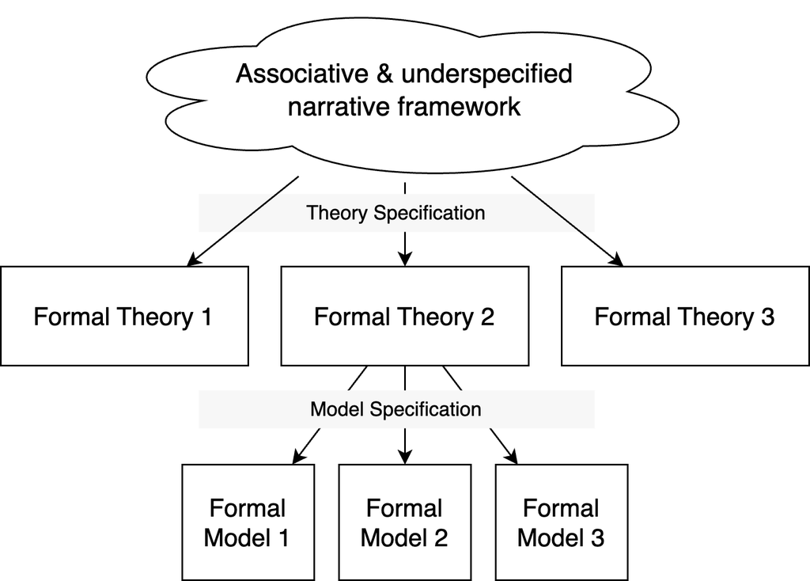

## Narrative - theory - model

**Theory Specification**: Deriving a precise formal theory from a narrative framework

- Multiple formal theories can be derived from a narrative framework
- Even if they are all compatible with the narrative framework, they can be mutually incompatible.
- Or they can be complementary (e.g., referring to different domains, or covering different aspects of the narrative framework), e.g. evolution as framework
- More *precise* narratives set more *constraints* on admissible formal theories (i.e., the set of compatible theories is smaller)

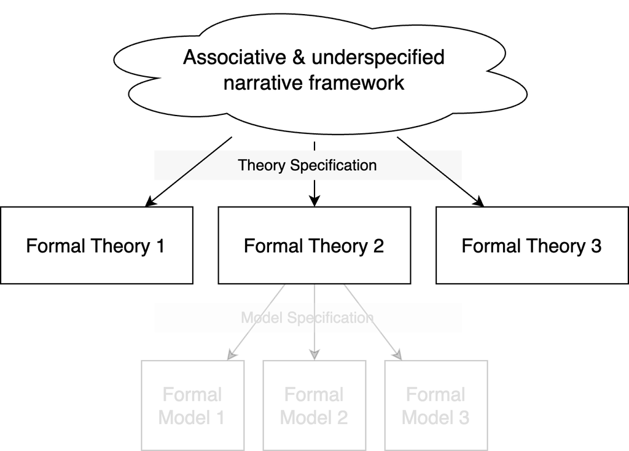

## Narrative - theory - model

**Model Specification**: Deriving a precise formal model from a theory

- Multiple formal models can be derived from a single theory
- Even if they are all compatible with the theory, they can be mutually incompatible due to different auxiliary assumptions.
- A *generative model* is so precise (and fully specified) that it can be used to generate “fake” data.
- Even if the concrete numerical predictions will differ, all admissible models should satisfy the theory’s core qualitative predictions within its scope (e.g., direction of effects, monotonicity)

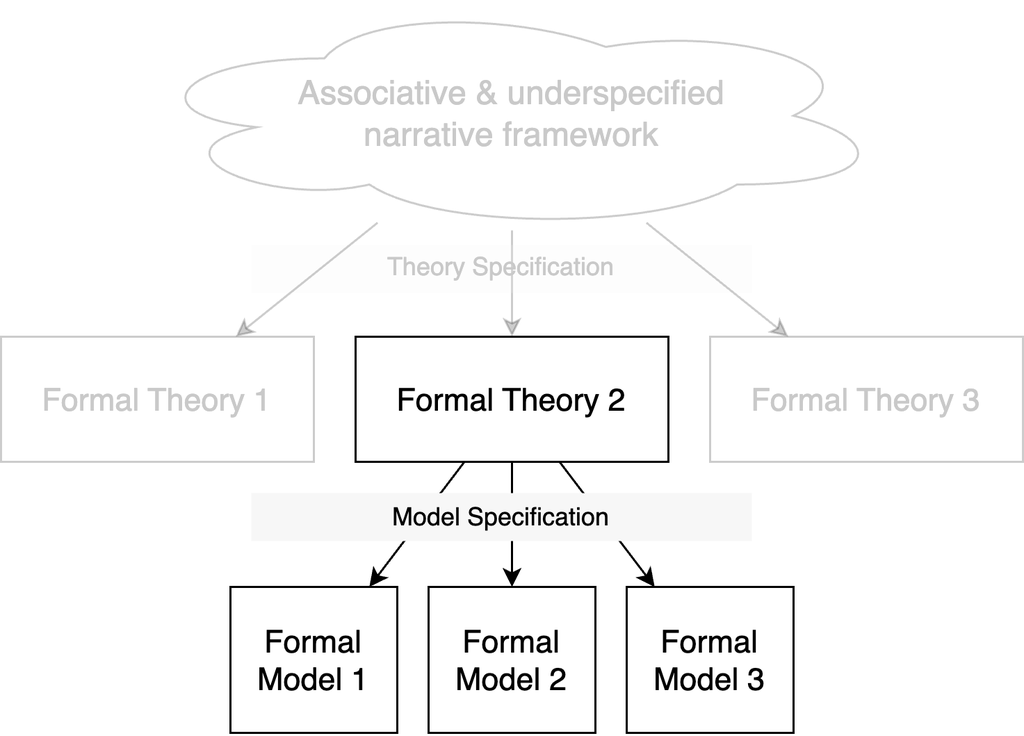

## What then are explanations?

With the definition of explanatory theories and formal models, a definition of explanations can be proposed:

> *“Theory T putatively explains phenomenon P”* means:

> **“if the world were as T says it is, P would follow as a matter of course.”**

> Although this notion of explanation is arguably incomplete, it has the advantages of being close to the commonsense understanding of the concept and being easy to implement in a formal model—namely by creating a virtual world in which theory T is true and showing that this world will indeed produce phenomenon P.

Charles S. Peirce (1931, p. 185); Borsboom et al. (2021). https://doi.org/10.1177/1745691620969647

## Understandability of explanations

Farrell & Lewandowsky (2018), referring to Trout (2007), emphasize the understandability of explanations:

- Explanations can “be epistemically valuable only if we could, implicitly or explicitly, understand them. As a result, explanation must maintain some contact with our psychological powers of understanding” (Trout, 2007, p. 565)
- “an explanation that cannot be understood is not an explanation”
- “some facts of the universe may remain irreducibly mysterious to humans - not because explanations do not exist in principle but because they cannot be humanly understood and hence cannot be formulated”
- “models in psychology benefit from simplifying the reality they seek to explain even though this simplification would likely render the model wrong. At the risk of being provocative, we would even argue that models are useful only **because** they are wrong.” (cf. von Uexküll!)

Farrell, S., & Lewandowsky, S. (2018). Computational Modeling of Cognition and Behavior. Cambridge University Press, Chapter 3. https://doi.org/10.1017/CBO9781316272503

## Definitions (2)

**What is an (explanatory) theory?**

A theory is a set of statements about the relationship(s) between two or more constructs with a law-like character.

**What is a formal model?**

A model is a precise mathematical or computational instantiation of some theory claims plus operationalizations and auxiliary assumptions. It is able to generate “fake” data and data patterns that would be observed in reality if the theory *and* the model are sufficiently accurate.

**What is an explanation?**

In the *productive explanation framework*, a theory $T$ putatively explains a phenomenon $P$ if and only if a formal model $M$ of the theory $T$ produces a statistical pattern representing the empirical phenomenon $P$.

```
%%{
  init: {
    'theme': 'base',
    'flowchart': { 'curve': 'natural' }
  }
}%%
flowchart LR
  T(Theory)
  P(Phenomena)
  D(Data)
  M(Model)

  T -- "Explanation" --> M
  M -- "Explanation" --> P
  P -- "Abduction" --> T
  P -- "Prediction" --> D
  D -- "Generalization" --> P
```

Borsboom et al. (2021). https://doi.org/10.1177/1745691620969647; van Dongen et al. (2023). https://doi.org/10.31234/osf.io/qd69g

# End

## Contact

- [@nicebread@scicomm.xyz](https://scicomm.xyz/@nicebread)
- ed.uml.ysp@tdorbneohcs.xilef
- https://www.nicebread.de
- https://github.com/nicebread

CC-BY-SA 4.0